# Hakai flow wrangling notes

## Author

Ian Giesbrecht wrote the code and had Claude tidy it up

## Purpose

This document is a breadcrumb trail of my exploration of Hakai’s 5-minute flow data (via `hydrocan`) and a list of comments and questions for Emily and Sam. It is **not** part of the SFF-BC pipeline — the actual data-pulling logic now lives in `R/get_hakai_flow_data.R`, which this document sources to generate the working dataset before exploring it.

```r
library(tidyverse)
library(hydrocan)
```

```r
# Parameters controlling the pull (see R/get_hakai_flow_data.R for details)
SiteList_hydrocan <- c("H08KC0626", "H08KC0693", "H08KC0703", "H08KC0708", "H08KC0819", "H08KC0844", "H08KC1015")  # or use whatever was set in the main pipeline
HAKAI_START_DATE <- "1900-01-01"  # pulls the full available record
MIN_OBS_PER_DAY <- 288 / 2 # minimum number of 5-min readings required to keep a day (out of a max of 288/day). Days below this threshold are dropped as unreliable daily means.

source(here::here("R", "get_hakai_flow_data.R"))
```

## **Review comment 1. Split quality_code?**

I see that quality_code combines a code and a description (e.g. “SVC: …”). My script extracts just the code so that can be used for filtering. Can Hakai split this at the source and publish the quality code and notes as two independent columns? I believe the `hydrocan` adapter system can accommodate that via `quality_code` vs `qf_desc`.

## **Review comment 2. Missing QC codes?**

As of August 2026, many 5-min readings have no QC code. **Is this expected, perhaps due to a backlog in the QC process or something else?**

My assumption is that all cases should have a QC code after QC work is complete.

Importance: if a user uses only “AV” records they would miss a large amount of otherwise-usable data.

```r
#Count cases of each QC_code
table_QC_code <- table(HI_Q_subdaily_data$station_id, HI_Q_subdaily_data$QC_code)
table_QC_code
```

```
                         AV      EV      MV     SVC
  H08KC0626  393777  826279   47314      11     181
  H08KC0693      28  642793     238       0       0
  H08KC0703 1265054       0     231    1688       0
  H08KC0708    3309  691795   11280       0    6291
  H08KC0819   84780  487465   51637       0   19164
  H08KC0844  394769  832692   14468    6023      13
  H08KC1015  617013  523313   15466       0  112039
```

## **Review comment 3. Unreported cases of missing flow values?**

As of August 2026, we have a quite a few *unreported* cases of missing flow values (i.e., not flow data but not explicitly flagged as MV). Could Hakai deal with this at the source by automatically adding the MV flag to all cases without flow data?

```r
# Extract cases (5-min time periods) with no flow data.
Missing <- subset(HI_Q_subdaily_data, is.na(value))
table(Missing$station_id, Missing$QC_code)
```

```
                       MV    SVC
  H08KC0626   3520     11    181
  H08KC0693     28      0      0
  H08KC0703  36327   1688      0
  H08KC0708    740      0   6291
  H08KC0819  84780      0  19164
  H08KC0844   5391   6014     13
  H08KC1015 119886      0 112039
```

## Review comment 4. Treatment of SVC and EV values

My script currently assigns an NA value to all records with a QC flag of SVC (erring on the side of caution). All other values (including EV, AV, and missing QC flags) are retained and passed through to the analysis. See `R/get_hakai_flow_data.R`. **Emily, would you agree this is an appropriate way to apply the QC flags and create an analysis ready dataset?**

```r
# Extract and inspect cases with suspect value flag.
SVC <- subset(HI_Q_subdaily_data, QC_code == "SVC")
```

## Review comment 5. Zero-flow values

There are many instances of zeros in the flow values column. My analysis assumes these are valid measurements that trully represent a state of no flow. **Emily, what is our level of confidence that these zeros represent true no-flow conditions? Do you recommend anything different to the user?**

```r
HI_Q_subdaily_data |>
  group_by(station_id) |>
  summarise(n_zero = sum(value == 0, na.rm = TRUE))
```

```
# A tibble: 7 × 2
  station_id n_zero
  <chr>       <int>
1 H08KC0626     122
2 H08KC0693       0
3 H08KC0703       0
4 H08KC0708       2
5 H08KC0819     154
6 H08KC0844     109
7 H08KC1015    3634
```

## Review comment 6. How to do daily aggregation?

My script computes a daily mean flow for all days with “enough” data. **Is my simple per-day mean (with a minimum-observations cutoff) an adequate substitute for WSC’s time-weighted daily mean approach, or should this be revisited?**

**If so, should we set a higher requirement such as 75% of the 5-min periods per day? i.e., MIN_OBS_PER_DAY <- 0.75 * 288**

WSC computes daily means as a time-weighted average of 5-min data between 0:00 and 24:00, interpolating endpoints if needed (excluding gaps >121 min): https://wateroffice.ec.gc.ca/contactus/faq_e.html#Q6

Hakai typically reports a reading at 0:00 (but not 24:00), so interpolation generally isn’t needed at the start of the day. My current approach in `get_hakai_flow_data.R` is simpler than WSC’s: a plain mean of available 5-min readings per day, dropping days with less than half the expected 288 readings (`MIN_OBS_PER_DAY`, set above). This is a simplification relative to WSC’s time-weighted method.

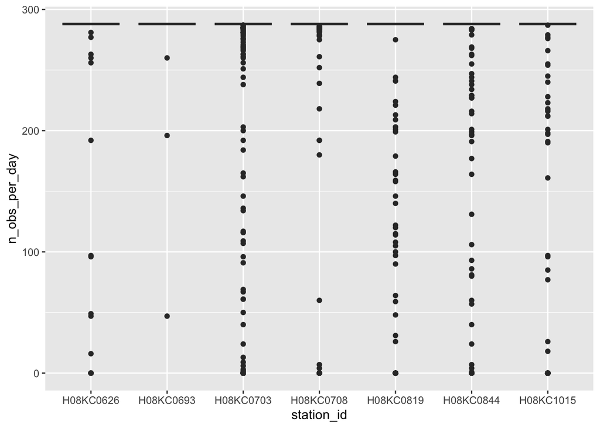

```r
ggplot(HI_Q_subdaily_data |>
         group_by(station_id, Date = date(timestamp)) |>
         summarise(n_obs_per_day = sum(!is.na(value)), .groups = "drop"),
       aes(station_id, n_obs_per_day)) +
  geom_boxplot()
```

With `MIN_OBS_PER_DAY = 288/2`, this drops a small fraction of days: as of June 2026, ~0.77% of days at 844 and ~0.32% at 626.

```r
HI_Q_data |>
  group_by(STATION_NUMBER) |>
  summarise(n_zero = sum(Value == 0, na.rm = TRUE))
```

```
# A tibble: 7 × 2
  STATION_NUMBER n_zero
  <chr>           <int>
1 H08KC0626           0
2 H08KC0693           0
3 H08KC0703           0
4 H08KC0708           0
5 H08KC0819           0
6 H08KC0844           0
7 H08KC1015          13
```

## Review comment 7. Who should do daily aggregation?

Would it be feasible for Hakai to push daily-aggregated data to ERDAP (alongside the 5-min data), rather than each downstream user re-deriving it like I have done? This would increase reproducibility given decisions that need to be made in the computation.

## Gauges excluded from the SFF-BC pipeline (for context)

- **703** - no accepted data and missing a lot of data
- **1015** - lake effect, large data gap, missing recent data
- **819**, **708** - deactivated

Only **626** and **844** are used downstream in SFF-BC at this time. If you want to explore different sets of gauges, adjust `SiteList_hydrocan` above and re-run.